# Mock Exam 1

claire

2018年10月14日

#### 1. [30%] 台北市某高中的小明和 4 位好友，一行共 5 人，放學後相約在學校門口旁的自行車租借站(A 站)，結伴騎乘公共自行車，到西門町(租借站 B 站)聚餐與逛街。

#### 已知 1：

#### A 站有 20 個車位，每個車位有腳踏車的機率為 0.2；

#### B 站有 40 個車位，每個車位有腳踏車的機率為 0.1。

#### 每個車位有無停放腳踏車皆是一個獨立事件。

#### 已知 2：

#### 台北市所有流通的公共自行車共有 200 輛，其中 5% 有輕微損壞(仍租借使用)。

#### 校方為了確保學生的交通安全，與自行車租賃業者合作進行調查，

#### 發現在所有輕微損壞的自行車中，有 10% 會出現在該校門口旁的 A 站。

#### a.這 5 位好友每個人同時都能在 A 站借車，且在 B 站能同時還車的機率。[10%]

```r
a<-dbinom(5, size = 20, prob = 0.2) #given x, size, prob --> probability
b<-dbinom(5, size = 20, prob = 0.9) #given x, size, prob --> probability
a*b
```

```
## [1] 1.598085e-12
```

#### △這樣是錯的，應該要算的是累積機率，因為只要超過5個就行

#### 正解

```r
na <- 20
pa <- 0.2
nb <- 40
pb <- 0.1

(1-pbinom(4, size=na, prob = pa)) * pbinom(35, size=nb, prob=pb)
```

```
## [1] 0.3703517
```

#### b.小明在 A 站會租到輕微損壞自行車的機率。[10%]

```r
#A暫租到腳踏車的機率*A站腳踏車壞掉的機率
a<-pbinom(19, size = 20, prob = 0.2)
b<-0.05*0.1
a*b
```

```
## [1] 0.005
```

#### △這樣是錯的，因為這題要算的是再租到車子的情況下所發生的損壞機率，要用P(B|A)=P(A∩B)/P(A)的概念，並且也不能將A事件想成小明在A站能借到腳踏車的機率，B是腳踏車壞掉的機率，然後把AB相乘，因為會有很多複雜的因素在裡面

#### 正解(但有爭議)

```r
#a代表在200台車中會在站點A的某台繳踏車的機率，b代表會在站點A的繳踏車且壞掉的機率
a<-20*0.2/200
b<-0.1*0.05
b/a
```

```
## [1] 0.25
```

#### c. 這 5 位好友中有 2 人在 A 站剛好租到輕微損壞自行車的機率。[10%]

```r
#5選2*(租到輕微損壞自行車的機率)^2
((5*4/2)*(b/a)^2)/2^5
```

```
## [1] 0.01953125
```

#### 錯誤，不知道為什麼

#### 正解(但有爭議)

```r
dbinom(2, size=5, prob=0.25)
```

```
## [1] 0.2636719
```

#### 2. [30%] 世貿捷運站晚上的每小時進出站人數是呈現常態分布。進站人數 (平均=80，標準差=5)；岀站人數 (平均=30，標準差=3)，且每小時的進出站人數互相獨立。 請計算下列問題：

#### a. 該捷運站的設計容量是以每小時停留站內的平均人數加上 3 倍標準差。計算該站可容納的人數。 (假設：站內人數 = 進站人數 – 出站人數) [10%]

```r
#a=站內平均 b=站內標準差
a<-80-30
b<-(5^2+3^2)^(1/2)#要記得要用+喔
contain<-a+b*3
contain
```

```
## [1] 67.49286
```

#### b. 為了因應跨年晚會人潮湧入捷運站，捷運局預估當晚每小時的進站人數會是平日的 3 倍，而每小時出站人數則為平日的 0.5 倍。定義跨年尖峰站內人數為當晚每小時站內的平均人數加上 3 倍標準差。計算該站的跨年尖峰站內人數。[10%]

```r
#D為當晚每小時的進站人數平均,d為當晚每小時的進站人數標準差；G為當晚每小時的出站人數平均，g為當晚每小時的出站人數標準差
D<-80*3
d<-5*3
G<-30*0.5
g<-3*0.5
yearmean<-D-G
yearstan<-(d^2+g^2)^(1/2)
yearamount<-yearmean+yearstan*3
yearamount
```

```
## [1] 270.2244
```

#### c.捷運局認為，若該站每小時站內人數“超過”200人，就需要加派人力引導疏散。請分別計算在平日晚上和跨年晚會，該站需要加派人力的機率。 [10%]

```r
normal<-1-pnorm(200, mean = a, sd = b) #given mean, sd --> cumulative probability
newyear<-1-pnorm(200, mean =yearmean , sd = yearstan)
normal
```

```
## [1] 0
```

```r
newyear
```

```
## [1] 0.9513811
```

#### 3. [25%]定義：每天遭竊率 (%) = (每天遭竊人數 / 總人口數) x 100%若某城市有 100 萬人口，每人每天會遭竊的機率 0.01。請回答下列問題：

#### a. 協助繪製該城市「每天遭竊人數」的機率分布圖 (probability distributionfunction, PDF)，並分別以綠色、藍色、黃色和紅色在圖上標示出「良好」、「普通」、「不良」、「危險」等區間。[10%]

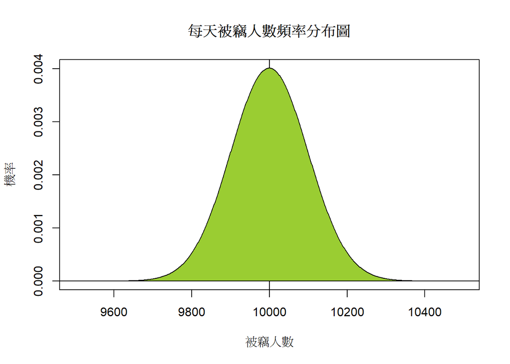

```r
xx = seq(0, 10^6)
yy = dbinom(xx, size = 10^6, prob = 0.01)
# Plotting
plot(x = xx, y = yy, type = "l",xlim=c(9500,10500),,ylab = "機率" ,xlab = "被竊人數" ,main="每天被竊人數頻率分布圖")
## Add a line on the plot
abline(v = 10000, col = "black")
## Highlight an area on the plot
region_g.x = xx[xx<=10^5]
region_g.y = yy[xx<=10^5]
region_g.x = c(region_g.x[1], region_g.x, tail(region_g.x,1))
region_g.y = c(0, region_g.y, 0)

polygon(region_g.x, region_g.y,density = -1, col = "yellowgreen")
```

##### 記得變數要換對，範圍要找好

#### b.模擬在一年(365 天)中的「每天遭竊人數」，並計算在這一年當中，「每天遭竊人數」會超出離群值(outlier)的日數。 [10%]

```r
table<-rbinom(365, size = 10^6, prob = 0.01) #random samples from a binomial distribution of given size, prob

quantile(table)
```

```
##    0%   25%   50%   75%  100%
##  9760  9923  9995 10074 10306
```

```r
min<-quantile(table)[2]-1.5*IQR(table)
max<-quantile(table)[4]+1.5*IQR(table)
outlier=0
for(i in 1:365){
if (table[i]>max|table[i]<min)#要記得加[i]
  outlier=outlier+1

}
outlier
```

```
## [1] 1
```

#### c. 若該城市警察加強巡邏，將每人每天會遭竊的機率降低為 0.001。重新繪製 a 小題的機率分布圖，並比較與描述兩張統計圖的差異。[5%]

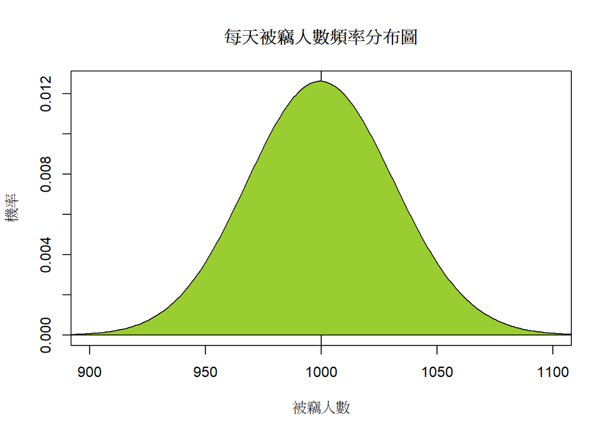

```r
xx = seq(0, 10^6)
yy = dbinom(xx, size = 10^6, prob = 0.001)
# Plotting
plot(x = xx, y = yy, type = "l",xlim=c(900,1100),,ylab = "機率" ,xlab = "被竊人數" ,main="每天被竊人數頻率分布圖")
## Add a line on the plot
abline(v = 1000, col = "black")
## Highlight an area on the plot
region_g.x = xx[xx<=10^5]
region_g.y = yy[xx<=10^5]
region_g.x = c(region_g.x[1], region_g.x, tail(region_g.x,1))
region_g.y = c(0, region_g.y, 0)

polygon(region_g.x, region_g.y,density = -1, col = "yellowgreen")
```

#### P(A|Bc) = 0.2

#### P(Ac|B) = 0.1

```r
A<-c("0.7-y","y","0.7")
AC<-c("0.3-(x-y))","x-y","0.3")
total<-c("1-x","x","1")
frame<-data.frame(A,AC,total)
row.names(frame)<-c("B","BC","total")
frame
```

```
##           A         AC total
## B     0.7-y 0.3-(x-y))   1-x
## BC        y        x-y     x
## total   0.7        0.3     1
```

#### 解聯立

#### P(A|Bc) = 0.2 = y/x

#### P(Ac|B) = 0.1 = 0.3-(x-y) / 1-x

```r
x <- 2/7
y <- 0.2*x
x
```

```
## [1] 0.2857143
```

```r
y
```

```
## [1] 0.05714286
```

#### 報準率:

```r
0.7-y+(x-y)
```

```
## [1] 0.8714286
```

#### b. 計算一週內（7 天）至少有一天氣象預報錯誤的機率。[10%]

```r
1-(0.7-y+(x-y))^7
```

```
## [1] 0.6183875
```

#### 5. [20%] 以下是在科學園區內的某一飲料店的每日營業時段與銷售量。

#### ★★★完全不會

#### 時間 10:00-14:00 14:01-16:00 16:01-21:00

#### 銷售量 (杯) 60 / 4 hours 30 / 2 hours 75 / 5 hours

#### 長期統計亦發現，任一時段皆有 60%的銷售量為含有珍珠的品項。

#### 老闆每天準備的珍珠量，可製作 75 杯飲品。假設每個時段的銷售是獨立事件。

#### 請回答下列問題：

#### a. 某人在 17:30 下班，已買不到珍珠奶茶的機率。[10%]

```r
#a=第一時段每分鐘賣出一杯的機率
a<-60/(4*60)
#b=第二時段每分鐘賣出一杯的機率
b<-30/(2*60)
#c=第三時段每分鐘賣出一杯的機率
c<-75/(5*60)
#有珍珠的
p<-0.25*0.6
1-pbinom(75, size = 60*7+30, prob = p) #given x, size, prob --> cumulative probability
```

```
## [1] 0.1457492
```

#### b. 每天的午休時間有20分鐘，其銷售量較高，平均是24/hour。請繪製午休時間銷售量的機率分佈圖。[10%]

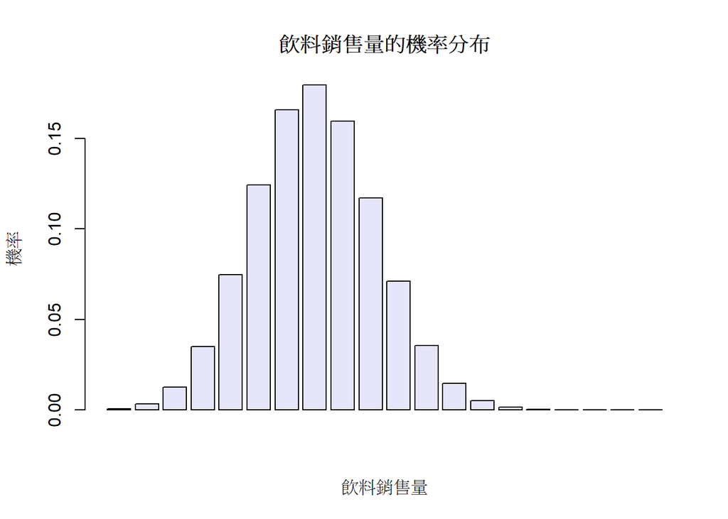

```r
#d=每分鐘賣出一杯的機率
d<-24/60
pro<-c()
for (i in 1:20){
  pro[i]=dbinom(i, size = 20, prob = d)
}

barplot(pro, col="lavender",xlab="飲料銷售量",ylab="機率",main="飲料銷售量的機率分布")
```